# Statistical Computing R HW #4

Alexis Zavez

November 6, 2016

[figure not shown]

# URMC Fitness Center Occupancy Analysis

## Introduction

The URMC fitness center is a private gym located inside the University of Rochester Medical Center. The fitness center is relatively small, so I am interested in determining which hours of the day are considered “peak” hours. Additionally, I am interested in determining whether some days are more crowded than others. I would also like to know whether or not the center is significantly more crowded on rainy days than non-rainy days. I recently joined the fitness center, and becoming more familiar with the crowds will help me plan my days more effectively. This analysis may be of interest to busy URMC students and employees who are also interested in tracking the URMC fitness center’s peak operating times.

## Method of Data Collection

Data were collected during each visit to the URMC fitness center between 9/9/2016 and 11/2/2016. There are five general areas of the facility: the studio, the squash courts, the gymnasium, the cardio equipment area, and the free weight area. I collected details on the number of members currently using each part of the facility, the current weather, as well as the date and time of the visit.

## Findings

My initial hypothesis was that the fitness center would be more crowded on rainy days than on clear days. On clear days, there are more opportunities to exercise outdoors, while on rainy days individuals are limited to indoor activities. However, my findings contradict this hypothesis. The mean number of members on clear days is higher than the mean number of members on rainy days. While both rainy and clear days appear to have the same minimum occupancy, the clear days mean, third quantile, and maximum occupancy counts are higher.

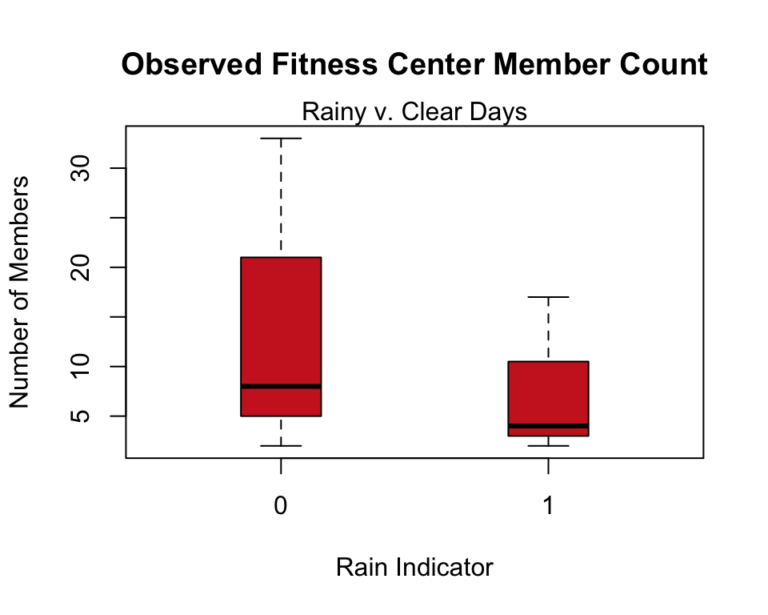

This analysis may be inconclusive due to a small, biased sample size. Of the 29 visits, only four were made on rainy days. Additionally, three of the four rainy day visits were made on Saturday. Looking at the plot of member count by day of week (see below), Saturdays tend to be less crowded than most other days of the week. The fitness center certainly gets less traffic on the weekends, as members seem to visit either before or after work during the week days. in fact, the distributions of members on Saturdays and Sundays are both lower than the week day distributions.

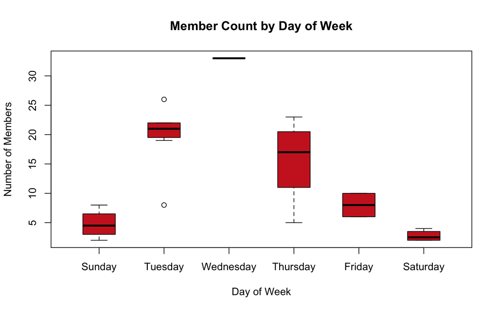

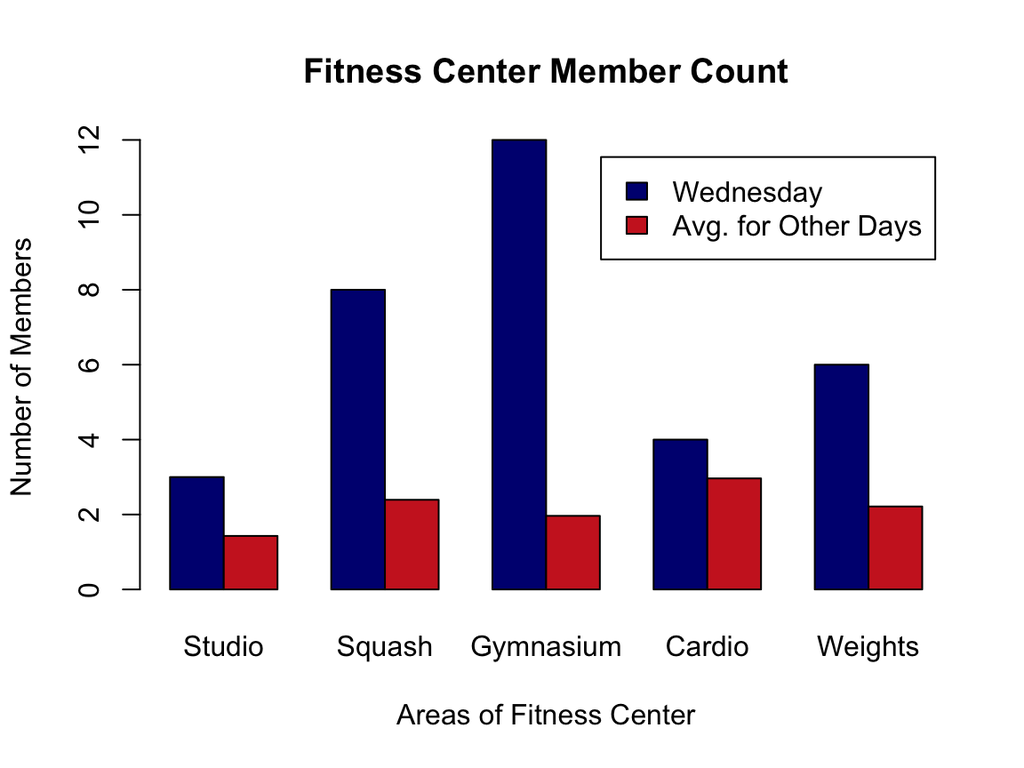

## Limitations to Findings

While the data collection process is fairly straightforward, there is certainly opportunity for bias. For example, my visits to the fitness center are not random or uniform. I tend to visit either early in the AM or in the later PM hours. This is apparent in the plot below. There are no visits between 9:00 AM and 4:00 PM. While this may be sufficient for members on a 9-5 schedule, there are many members (nurses, doctors, etc.) who work alternative hours. For this reason, the analysis may be more helpful if data could be collected at consistent intervals throughout the day.

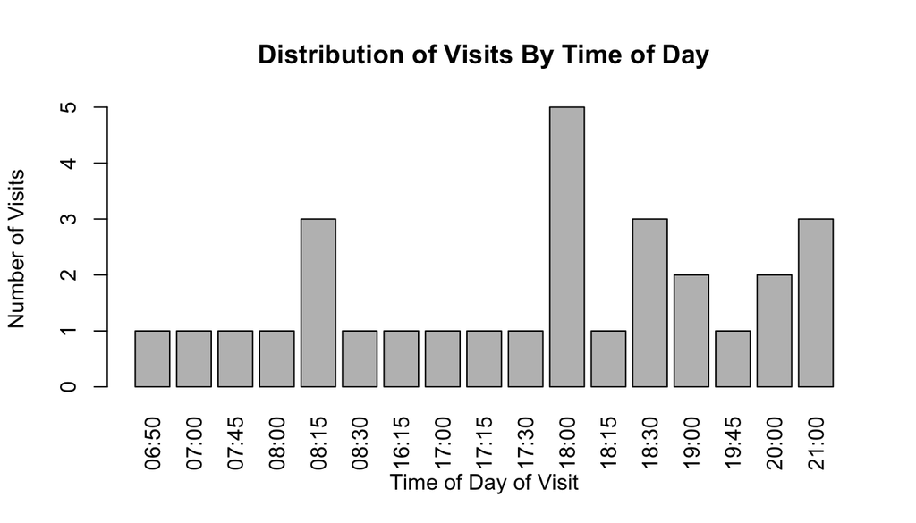

## Future Analysis

In the future, it would be best to have multiple data collectors who visit the fitness center throughout the day. If additional members participated and recorded data, this analysis could be much more meaningful. In addition to collecting data on the weather (rainy v. clear), it would have also been helpful to collect data on temperature. This would have provided an additional level of analysis.